# CharinusENM

João Frederico Berner

###### Andrea and Sara: I know you wanted something simple and small, but I’ve decided to catch up on some work I owed my co-advisor, and implement some things I had been playing around with. On top of that, I also really wanted to make it reproducible, and the scripts I had from my dissertation **were not**, so this was all pretty much from scratch. Also, this is in html and not pdf for two reasons: alternative text in the figures and the final plot, which doesn’t work with pdf and I feel is the best way to explore ENM outputs in detail.

# Charinus Ecological Niche Models

## Present to LGM projections

### **Overview**

##### This model is part of a population genetics study, led by Gustavo Silva de Miranda and collaborators. They aim to see if the following Ecological Niche Models fit the divergences found in their phylogenies.

#### **Taxon, Location, Predictors, Scale**

The focus taxon is a whip-spider (Arachnida:Amblypygi) clade of the genus *Charinus*. The genus has a pantropical distribution, while the focus clade occurs only in the Brazilian Atlantic Forest, in the Rio de Janeiro and Espírito Santo states.

### **Data**

#### Occurence Data

Occurrence data has been collected in the field using GPS devices by the lead author of the study, all coordinates have uncertainty <30m. The data consists of both presence (n = 23) and absence (n = 6) records. We divide this dataset into two (`R/01_Occ_to_shp.R`) in for training (17 presences) and testing (6 absences and 6 presences) and create shapefiles (`data/processed/shapefiles/`) to use in building and plotting the models. See the distribuition of occurrence data at the end of this script. Accessible area (M) (Barve et al., 2011) was defined as the bounding box of a set of buffers of 200km diameter around occurrence records. All environmental layers were cropped by this limit (`R/02_Env-crop.R`).

##### Climatic Data

| Period | Dates (kya) |
| --- | --- |
| Late Holocene | 4.2 - 0.3 |
| Mid Holocene | 8.326 - 4.2 |
| Early Holocene | 11.7 - 8.326 |
| Younger Dryas Stadial | 12.9 - 11.7 |
| Bølling-Allerød Period | 14.7 - 12.9 |
| Heirich Stadial 1 | 17.0 - 14.7 |
| Last Glacial Maximum | 130 |

### **Model Fitting**

Models were built `R/03_Model-Build.R` using the aforementioned train and test data. We chose five algorithms to build them (SVM, MaxEnt, BRT, BioClim and Domain-dismo), with five bootstrap replicas each. All BRT models failed.

#### Model Outputs

##### MaxEnt Map output

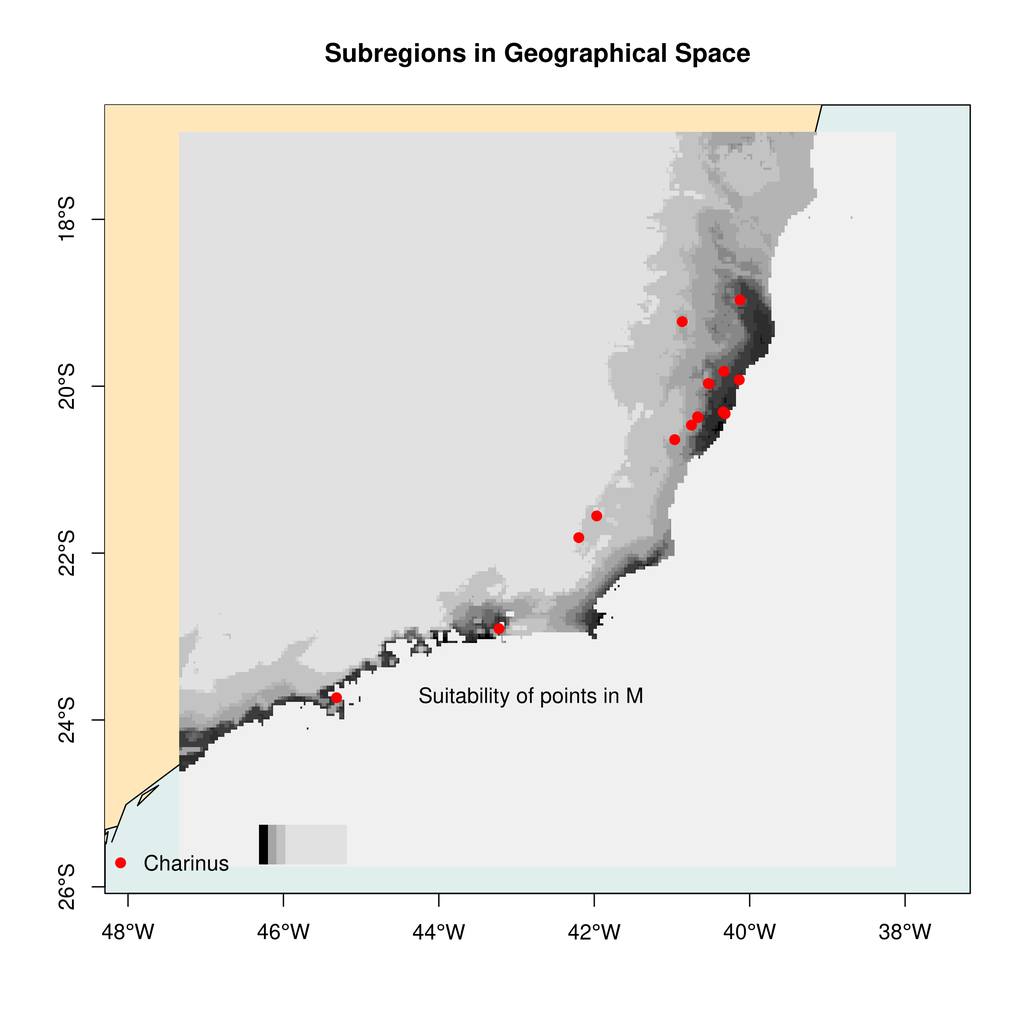

Map output of MaxEnt model, as an example. From `04_Model-evaluation.R`

##### MaxEnt Environmental output

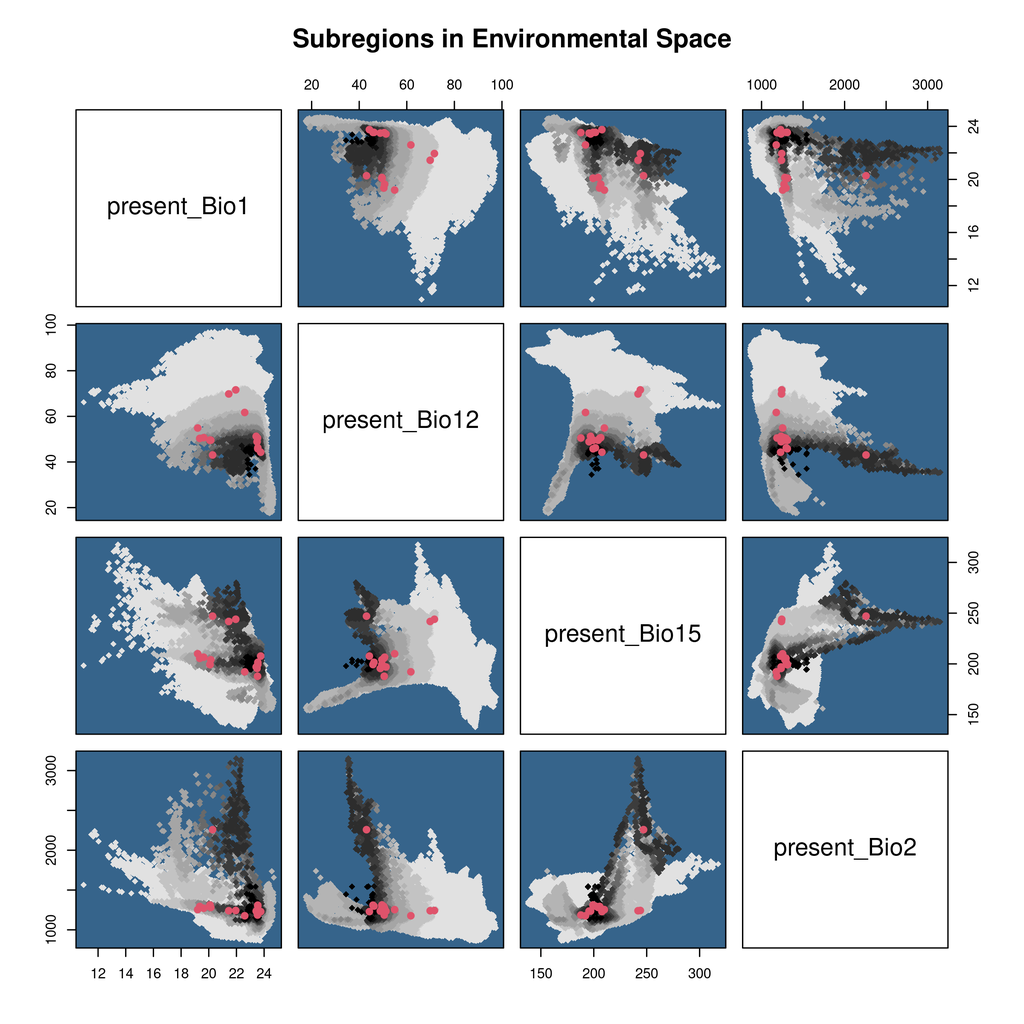

Output of MaxEnt model, occurrence records and suitability regions in environmental space. From `04_Model-evaluation.R`

##### Model output

```r
model <- sdm::read.sdm('../data/processed/model-build/model-object/model.sdm')

model
```

```
## class                                 : sdmModels
## ========================================================
## number of species                     :  1
## number of modelling methods           :  5
## names of modelling methods            :  svm, maxent, brt, bioclim, domain.dismo
## replicate.methods (data partitioning) :  bootstrap
## number of replicates (each method)    :  5
## toral number of replicates per model  :  5 (per species)
## ------------------------------------------
## model run success percentage (per species)  :
## ------------------------------------------
## method          charinus
## --------------------------
## svm            :          100   %
## maxent         :          100   %
## brt            :          0   %
## bioclim        :          100   %
## domain.dismo   :          100   %
##
## ###################################################################
## model Mean performance (per species), using independent test dataset:
## -------------------------------------------------------------------------------
##
##  ## species   :  charinus
## =========================
##
## methods      :      AUC     |     COR     |     TSS     |     Deviance
## -------------------------------------------------------------------------
## svm            :     0.58    |     0.2     |     0.3     |     1.82
## maxent         :     0.62    |     0.18    |     0.4     |     1.53
## brt            :     NA       |     NA       |     NA       |     NA
## bioclim        :     0.4     |     -0.17   |     0.08    |     5.03
## domain.dismo   :     0.67    |     0.29    |     0.47    |     2.08
```

### **Assessment**

#### Model Evaluation

We then evaluate these models by with the accumulation of occurrences curve (Jiménez & Soberón, 2020) `R/04_Model-evaluation.R`, alongside the mean AUC score `05_AUC_values.R` (which is less problematic since we tested with absence data).

To run the [accum.occ](https://github.com/LauraJim/SDM-hyperTest/blob/master/Accum_curve_occ.R)() function, the sdm and the predict object had to be manipulated alongside the occurrence records and the environment used in prediction. We built two functions to prepare the data (`R/sdm_to_occ.pnts.R` & `R/sdm_to_output.mod.R`), regarding the two objects required by the AOcC function. The outputs of [accum.occ](https://github.com/LauraJim/SDM-hyperTest/blob/master/Accum_curve_occ.R)() and [comp.accplot](https://github.com/LauraJim/SDM-hyperTest/blob/master/compare_models.R)() are in `figs/aocc/`.

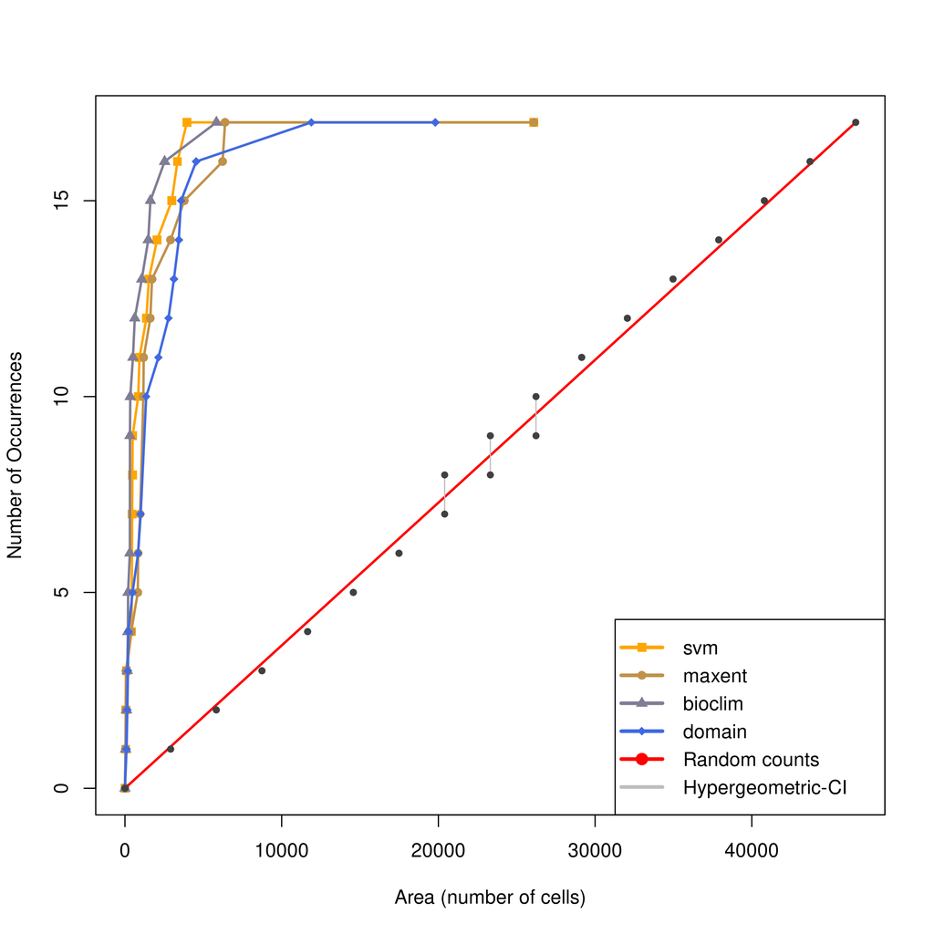

Accumulation of occurrences curves comparing the performance of the four tested algorithms.

The evaluation of these final models (`R/07_Final-Model_Evaluation.R`) and their outputs and predictions are stored in `data/processed/final-model-build/`.

### **Predictions**

With the final models at hand, we projected them to the PaleoClim layers (`08/Predictions-Past.R`), and finally ensembled the two models, wheighing by the AUC values. The last step was binarizing the outputs of the ensembled projections by a 0.4 threshold (`09_Ensemble_Preds.R`).

As a final step, we projected all layers along with the occurrence records on the following interactive map (`R/10_leaflet-map.R`):

[interactive chart not shown]

Interactive map of ensembled presence/absence predictions. (Only works in the html version of this document)

#### **References**

Barve, N., Barve, V., Jiménez-Valverde, A., Lira-Noriega, A., Maher, S. P., Peterson, A. T., … Villalobos, F. (2011). The crucial role of the accessible area in ecological niche modeling and species distribution modeling. *Ecological Modelling*, *222*(11), 1810–1819. doi: 10.1016/j.ecolmodel.2011.02.011

Hijmans, R. J., Cameron, S. E., Parra, J. L., Jones, P. G., & Jarvis, A. (2005). Very high resolution interpolated climate surfaces for global land areas. *International Journal of Climatology*, *25*(15), 1965–1978. doi: 10.1002/joc.1276

Jiménez, L., & Soberón, J. (2020). Leaving the area under the receiving operating characteristic curve behind: An evaluation method for species distribution modelling applications based on presence-only data. *Methods in Ecology and Evolution*, *11*(12), 1571–1586. doi: 10.1111/2041-210X.13479